**tino@github**: ~/blog — --:--:--

cat posts/quadratic-approximation.md

# Quadratic Approximation for Bayesian Inference

Sep 23, 2022 bayesianinference

## It’s been a minute!

Hi! It’s been a long time since I last posted on this blog. There are multiple reasons for that:

1. Work has become more demanding, which means I have less time devote to writing.
2. I have started a M.Sc. program in Machine Learning and Data Science.

Going back to school is allowing me to partially fill the void in statistics that many years of engineering have left behind. Even though I was on the Neural Networks hype when I started this blog, I am beginning to find Statistics (with the capital “S”) more and more interesting. As a result, I have decided that I will focus on a broader range of topics - which for the most part will be statistics-related.

Although I have tried publishing on Medium in the past, I feel that the platform is not mature enough for anything related to math. The lack of MathJax support was a big disappointment in my case.

Without further ado, let’s begin!

## Background

Many of the readers may have come across Bayesian inference in the past. A bit of details on the procedure are explained here.

The Bayesian framework allows the statistician to incorporate prior beliefs into the inference process. By *prior*, we mean the “knowledge” we think we might have about something *before* we observe anything related to it. Frequentists may call it *prejudice*, but Bayesians argue that, no matter how fair and objective we think we are, there will always be some sort of subjectivity in the analysis. Think about this: when you propose a model and a *likelihood* function for a certain model, you are already incorporating your prior belief of what that model’s output data should look like. Isn’t that, already, a subjective statement?

Bayesians accept this subjectivity, and use the Bayes’ theorem to update their beliefs about the model’s parameters. A statement of the Bayes’ Theorem is included in Equation 1:
$$\begin{equation}
\textrm{posterior} = \frac{\textrm{likelihood} \times
\textrm{prior}}{\textrm{evidence}} \label{eq1}\tag{1}
\end{equation}$$

The denominator of Equation (1), the *evidence*, although dependent on the particular form of chosen likelihood and prior distribution, is **constant**. This denominator is itself the root of all the hardships of Bayesian Statistics: as the parameter space grows in dimensions (1 dimension for each parameter implies a 20-dimensional space for 20 parameters, for example) calculating this high-dimensional integral becomes extremely hard and computationally unfeasible. This is exactly the reason why **Markov Chain Monte Carlo (MCMC)** (I have written an article on Medium about it, you can find it [here](https://medium.com/@tinonucera/bayesian-linear-regression-from-scratch-a-metropolis-hastings-implementation-63526857f191)) has gained popularity and is the **most reliable technique for Bayesian inference, as long as you use it properly**.

Another approach, which is very simple and sometimes brings satisfactory results, is the Quadratic Approximation. Which I will discuss below.

## Explanation

The Bernstein-Von Mises Theorem states that, under some regularity conditions (which are detailed, for example, [here](https://arxiv.org/pdf/1907.09611.pdf)) the posterior distribution is asymptotically normal. Remember, this is an *asymptotic result* which means it may or may not hold true, depending on how much data you have.

The Quadratic Approximation uses this asymptotic result to approximate the posterior with a normal distribution. How is the probability density function of this - possibly multivariate - normal distribution obtained? Well, we know that a normal is fully identified by two parameters:
$$\begin{equation}
Z \sim \mathcal{N}(\theta,\Sigma_\theta)
\end{equation}$$

$\theta \in \mathbb{R}^n$ is the mean and $\Sigma_{\theta} \in \mathbb{R}^{n\times n}$ is the covariance matrix (which is positive semi-definite by definition). Approximating the posterior with a multivariate normal means calculating these two parameters $\mu$ and $\Sigma$.

Recall that, if $\mu$ is the mean of the multivariate normal distribution, then this must also be the median and the **mode**. The fact that the mean and the mode coincide is useful because the mode is the highest value in the distribution. As a result, in order to find $\mu$, we may use any maximization technique we like (well, not really, but bear with me for now).

Now, let’s look at the Bayes’ Theorem once again (in Equation 1). Since the *evidence* is a constant, the maximum of the fraction on the right hand side corresponds to maximizing the numerator only. We can then write a proportional relationship:
$$\begin{equation}
\textrm{posterior} \propto \textrm{likelihood} \times \textrm{prior}
\end{equation}$$
Or, in logarithmic terms:
$$\begin{equation}
\log(\textrm{posterior}) \propto \log(\textrm{likelihood})
+ \log(\textrm{prior})
\end{equation}$$

We can then apply the Taylor’s Theorem on the log-posterior (I will refer to it as $\textrm{logp}$ from this moment on), and build a second-order approximation:
$$\begin{equation}
\textrm{logp}(\theta) \approx \textrm{logp}(\mu) + \nabla
\textrm{logp}(\mu)(\theta-\mu) + \frac{1}{2} (\theta-\mu)^T \nabla
\otimes \nabla \textrm{logp}(\mu)(\theta-\mu)
\end{equation}$$

Mind you: $\theta$ and $\mu$ are, in general, vectors, and they contain the quantities we are trying to infer on. As we said before, we are approximating the normal around its maximum $\mu$. This means that the gradient $\nabla \textrm{logp}(\mu)$ must be zero. The Taylor’s approximation then simplifies to:
$$\begin{equation}
\textrm{logp}(\theta) \approx \textrm{logp}(\mu) + \frac{1}{2}
(\theta-\mu)^T \nabla \otimes \nabla \textrm{logp}(\mu)(\theta-\mu)
\end{equation}$$
Next, observe that $\nabla \otimes \nabla \textrm{logp}(\mu)$ is the Hessian matrix at the maximum. I have decided to make the outer product explicit to avoid confusion with the laplacian operator. We can call this quantity $H$ to make it look more friendly.
$$\begin{equation}
\textrm{logp}(\theta) \approx \textrm{logp}(\mu) + \frac{1}{2}
(\theta-\mu)^T H(\mu)(\theta-\mu)
\end{equation}$$

Do you remember when I said we could use any optimization technique we like? Well, I was lying. We can’t (or at least shouldn’t). If our optimization algorithm uses an approximation of the Hessian matrix for the iterations, we may use such approximation of the Hessian to construct an estimator of the covariance matrix of the posterior distribution. The Broyden–Fletcher–Goldfarb–Shanno algorithm (BFGS) is one of a larger family of algorithms which relies on the progressive improvement of the estimate of the Hessian. But why is the Hessian so important? because the Hessian is equivalent to the negative [*observed Fisher Information*](https://en.wikipedia.org/wiki/Fisher_information).

In particular:
$$\begin{equation}
H(\mu) = - \mathcal{I}(\mu) = \frac{\partial^2}{\partial \theta_i
\partial \theta_j}\textrm{logp}(\theta)\Big|_{\theta=\mu}
\end{equation}$$

And also, asymptotically, we have that the covariance matrix evaluated at the maximum ($\Sigma_\mu$) is the inverse of the observed Fisher information:
$$\begin{equation}
\Sigma_\mu = [\mathcal{I}(\mu)]^{-1}
\end{equation}$$

Recalling that in our assumption the posterior is normal leads to the following result:
$$\begin{equation}
\theta | Z \sim \mathcal{N}(\mu, \Sigma_\mu)
\end{equation}$$

And this is mostly the end of the theoretical explanation. The following section will show how to code a quadratic approximation to draw samples from the posterior of a Bayesian linear regression model. We use such a simple model because the posterior is readily available and the comparison becomes easy.

## Code

First of all, we need to import all the relevant libraries.

```python
from sklearn.datasets import make_regression # for a dummy data set generation
import numpy as np
np.random.seed(42)
import scipy.stats as scio
import matplotlib.pyplot as plt
from scipy.optimize import minimize
import pandas as pd
import seaborn as sns
import matplotlib.pyplot as plt
plt.rcParams["figure.dpi"] = 150
```

Then we use the `make_regression` function to create a dummy data set for regression.

```python
X, y = make_regression(n_samples=100,n_features=2, bias=0.0)
```

A linear model can be defined through the following conditional probability statement.
$$\begin{equation}
y | X, \beta, \sigma \sim \mathcal{N}(X\beta, \sigma^2 I)
\end{equation}$$
where:

- $y \in \mathbb{R}^{n}$ is the response vector
- $X \in \mathbb{R}^{n \times d}$ is the design matrix
- $\beta \in \mathbb{R}^{d}$ is the parameter vector
- $\sigma^2$ is a variance parameter (which sets the noise level)

In order to obtain an “easy” posterior, we use the conjugate prior on $\beta$ and $\sigma$ (normal-inverse-gamma):
$$\begin{align}
& \beta | \sigma \sim \mathcal{N}(0, \sigma^2 V) \\
& \sigma^2 \sim \textrm{invGamm}(a,b) \\
\end{align}$$
where $V = \lambda^{-1} I$ The choice of $\lambda$ is entirely up to us to decide.

### Exact Posterior

In [this book](https://link.springer.com/book/10.1007/978-3-030-82808-0) at chapter 8, proposition 8.1, it is shown that, for such model, the posterior is:
$$\begin{align}
& \beta | \sigma, X, y \sim \mathcal{N}(m_n, \sigma^2 V_n) \\
& \sigma^{2} | X, y \sim \textrm{invGamma}(a_n, b_n)
\end{align}$$
where:
$$\begin{align}
& V_n = (V^{-1}+X^TX)^{-1}\\
& m_n = V_n X^T y \\
& a_n = a + n/2 \\
& b_n = b+\frac{1}{2}(y^Ty-y^TXm_n)
\end{align}$$
The derivation of the exact posterior is not the main concern of this post, so the interested reader can refer to the mentioned book for that. We just need the exact posterior for comparison with the approximate one. First, we will place a prior on all the parameters:

```python
a, b = 1,1
lam = 0.01
V = 1/lam * np.eye(X.shape[1])
```

The parameters of the posterior will then be:

```python
n = X.shape[0]
Vn = np.linalg.pinv(np.linalg.pinv(V)+X.T@X)
mn = Vn@X.T@y
an = a+n/2
bn = b+0.5*(np.dot(y,y)-np.dot(y,X@mn))
```

We then draw 10000 samples from the posterior of $\sigma^2$ and, conditional on these values, draw the parameter $\beta$ from the multivariate normal. We then create a Pandas `DataFrame` with the beta samples and produce a seaborn `jointplot`:

```python
sigma2_post = 1/scio.gamma(a=an, scale=1/bn).rvs(10000)
beta_post = np.zeros((2,sigma2_post.shape[0]))
for i, sigma2_eval in enumerate(sigma2_post):
    beta_post[:,i] = scio.multivariate_normal(mean=mn, cov=sigma2_eval*Vn).rvs()

df_exact = pd.DataFrame()
df_exact["beta_1"] = beta_post[0,:]
df_exact["beta_2"] = beta_post[1,:]

graph1 = sns.jointplot( x = df_exact["beta_1"],
                        y = df_exact["beta_2"],
                        kind = 'hex',
                        xlim = [87.3, 88.3], ylim = [73.6, 74.5])
graph1.set_axis_labels(xlabel="$\\beta_1$",ylabel="$\\beta_2$")
```

The picture below shows 10000 samples from the exact posterior for $\beta$.

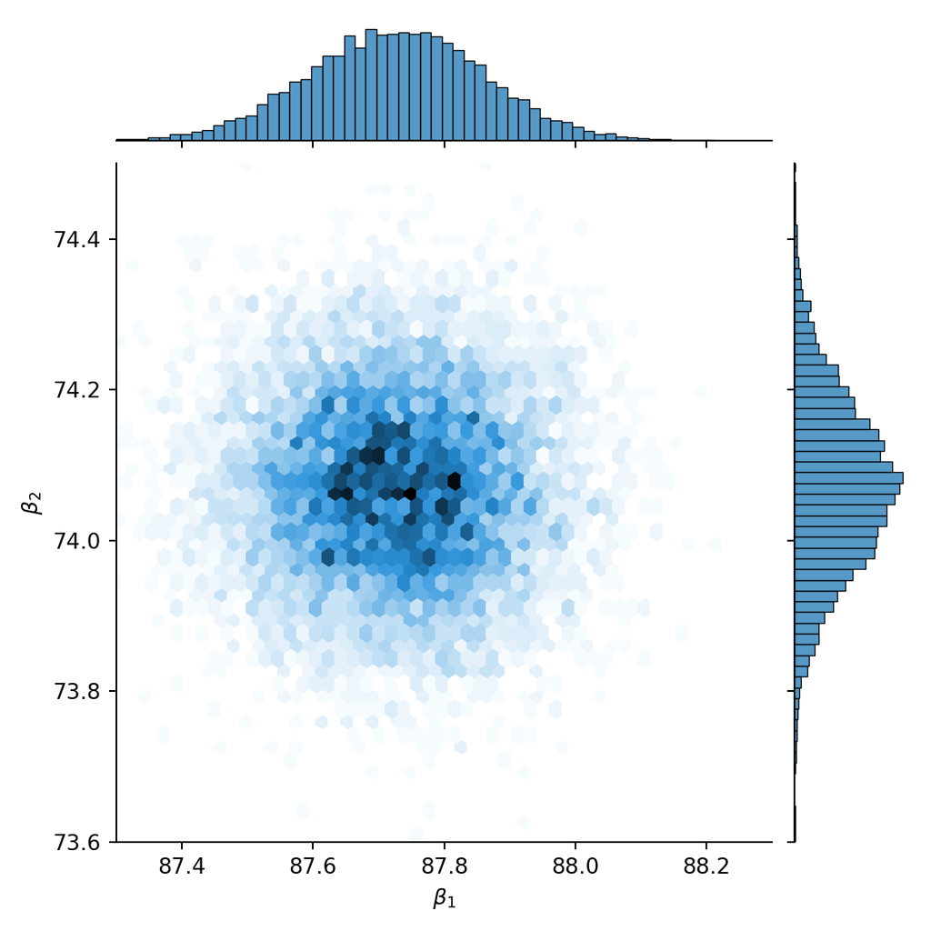

### Approximate Posterior

For the approximate posterior, we need to write the $\textrm{logp}$ (unnormalized log-posterior) to be maximized. There are two things to consider at this point:

- Scipy’s optimization routine performs minimizations. We need a maximization. In order to turn a maximization problem into a minimization one, all we need to do is to change the sign of the objective function so that maximizing $\textrm{logp}$ can be done by minimizing $-\textrm{logp}$.
- $\sigma^2$ is constrained to be strictly larger than zero. In order to discourage the optimization routine from returning illegal values of $\sigma^2$, we return an infinitely large negative log-posterior when $\sigma^2 \leq 0$.

Consider that, if $\sigma^2$ needs to be strictly larger than zero, the parameter space $\sigma^2$ is defined on is not compact. This implies a violation of the Bernstein-Von Mises theorem. How gross this violation is depends on the use we make of the results. Also, remember that $\sigma^2$’s posterior does not follow a normal distribution but an inverse Gamma, although we knew very well in advance we would be dealing with an approximation.

Before showing the objective function, recall that, for the log posterior:
$$\begin{equation}
\textrm{logp} \propto \log(\textrm{likelihood}) + \log(\textrm{prior})
\end{equation}$$

The objective function to minimize is included below. Note how the unnormalized log-posterior is the sum of three terms: one for $\sigma^2$ (the prior on the variance parameter is an inverse-Gamma), one for $\beta$ (the prior on the coefficients of the covariates is a multivariate normal) and, finally, the log-likelihood of the model (which is again multivariate normal).

```python
def objective(pars,a=1, b=1, lam = 0.01):
    beta = np.array(pars[:2])
    sigma2 = pars[2]
    if pars[2] <=0:
        # returns infinite negative logp when sigma^2 <= 0
        return np.inf
    V = 1/lam * np.eye(X.shape[1])
    # logpdf of sigma
    logp  = scio.invgamma( a =1, scale = 1/b).logpdf(sigma2)
    # logpdf of beta
    logp += scio.multivariate_normal(mean = np.zeros(beta.shape), cov = sigma2*V).logpdf(beta)
    # log likelihood
    logp += scio.multivariate_normal(mean = np.squeeze(X@beta.reshape(-1,1)),
                                     cov=sigma2*np.eye(X.shape[0])).logpdf(y)
    return -logp
```

We then call the optimization routine:

```python
opt= minimize(objective, x0=np.array([0.5,0.5,0.5]),method="BFGS")
```

As we explained before, we use the popular `BFGS` for optimization, as it naturally returns the inverse of the Hessian matrix which can then be used for sampling the posterior from the approximation (recall that in the previous section we explained that the Observed Fisher Information and the Hessian of the negative log-posterior are the same thing). `x0` is the array of initial guesses for the optimization. The first two parameters are the two components of $\beta$, while the third is $\sigma^2$.

The output of the optimization, `opt`, is really all we need. We can now sample from the approximate posterior. The results are included below.

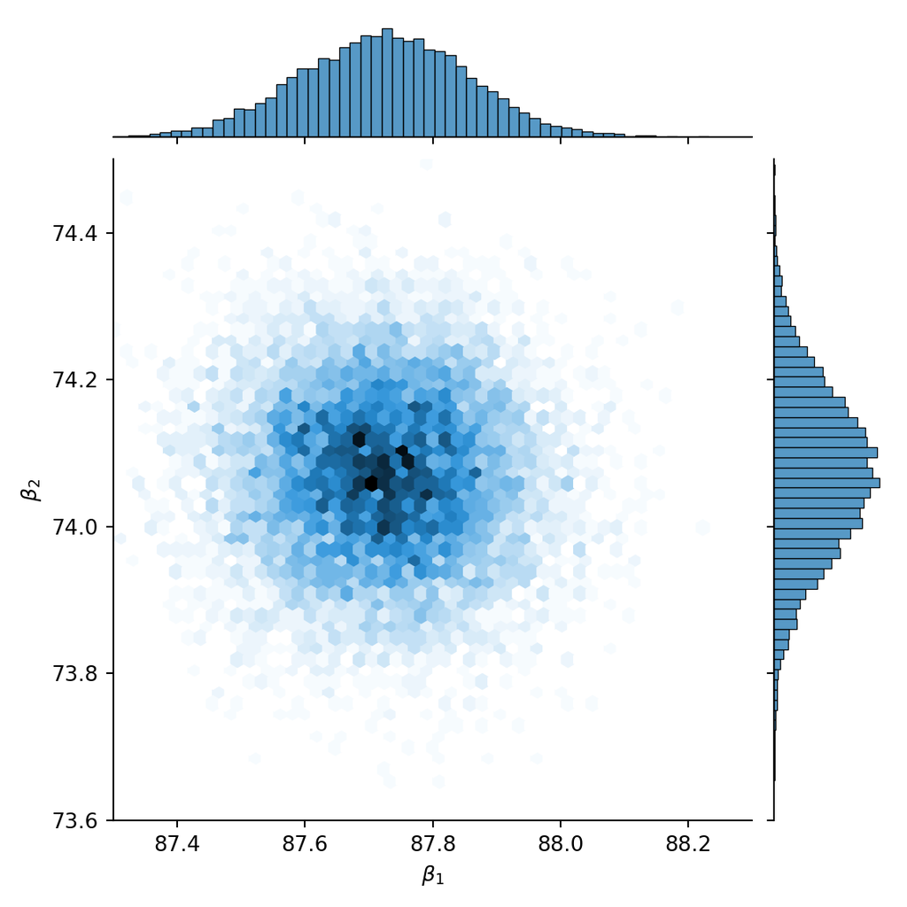

```python
params_approx = scio.multivariate_normal(mean=opt["x"], cov=opt["hess_inv"]).rvs(10000)
df_approx = pd.DataFrame({"beta_1":params_approx[:,0],
                          "beta_2":params_approx[:,1]})
graph2 = sns.jointplot( x = df_approx["beta_1"],
                        y = df_approx["beta_2"],
                        kind = 'hex',
                        xlim = [87.3, 88.3], ylim = [73.6, 74.5])
graph2.set_axis_labels(xlabel="$\\beta_1$",ylabel="$\\beta_2$")
```

If we visualize the two bivariate normal distributions for $\beta$ side by side, they look almost exactly the same.

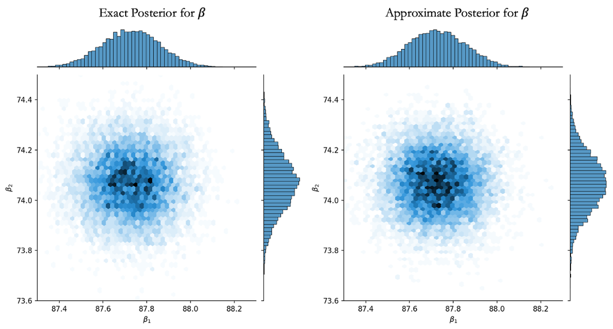

## Conclusion

We showed how to code the quadratic approximation of the posterior distribution. In addition, we explained that this approximation may or may not be appropriate, depending on:

1. the particular models and parameters in use
2. how close the bulk of the posterior density is to the boundaries of the parameter space

This code can be easily improved on by adding a parser for the specific distributions, so that the model can be fed, for example, via an external plain text file.

Although the approximation should be working well with arbitrary complex models, the normality of the posterior distribution is an asymptotic result, which means that it must hold true when the number of data points becomes arbitrarily large. However, for small-data problems, Markov Chain Monte Carlo could be a more suitable option.

Thanks for reading to the very end.

[figure not shown]

[Home](https://tinosai.github.io/)

$ cd .. → back to index